# Part I - (Fuel Dataset Exploration)

## Preliminary Wrangling

```python
# import all packages and set plots to be embedded inline
import numpy as np
import pandas as pd
import matplotlib.pyplot as plt
import seaborn as sns

%matplotlib inline
```

```python
#Load the dataset
df = pd.read_csv("fuel-econ.csv")
```

```python
# Get a look at the dataset
df.head()
```

|  | id | make | model | year | VClass | drive | trans | fuelType | cylinders | displ | pv2 | pv4 | city | UCity | highway | UHighway | comb | co2 | feScore | ghgScore |
| --- | --- | --- | --- | --- | --- | --- | --- | --- | --- | --- | --- | --- | --- | --- | --- | --- | --- | --- | --- | --- |
| 0 | 32204 | Nissan | GT-R | 2013 | Subcompact Cars | All-Wheel Drive | Automatic (AM6) | Premium Gasoline | 6 | 3.8 | 79 | 0 | 16.4596 | 20.2988 | 22.5568 | 30.1798 | 18.7389 | 471 | 4 | 4 |
| 1 | 32205 | Volkswagen | CC | 2013 | Compact Cars | Front-Wheel Drive | Automatic (AM-S6) | Premium Gasoline | 4 | 2.0 | 94 | 0 | 21.8706 | 26.9770 | 31.0367 | 42.4936 | 25.2227 | 349 | 6 | 6 |
| 2 | 32206 | Volkswagen | CC | 2013 | Compact Cars | Front-Wheel Drive | Automatic (S6) | Premium Gasoline | 6 | 3.6 | 94 | 0 | 17.4935 | 21.2000 | 26.5716 | 35.1000 | 20.6716 | 429 | 5 | 5 |
| 3 | 32207 | Volkswagen | CC 4motion | 2013 | Compact Cars | All-Wheel Drive | Automatic (S6) | Premium Gasoline | 6 | 3.6 | 94 | 0 | 16.9415 | 20.5000 | 25.2190 | 33.5000 | 19.8774 | 446 | 5 | 5 |
| 4 | 32208 | Chevrolet | Malibu eAssist | 2013 | Midsize Cars | Front-Wheel Drive | Automatic (S6) | Regular Gasoline | 4 | 2.4 | 0 | 95 | 24.7726 | 31.9796 | 35.5340 | 51.8816 | 28.6813 | 310 | 8 | 8 |

```python
#Look at the rows and columns in  the dataset
df.shape
```

```
(3929, 20)
```

```python
#Get some brief information on the dataset
df.info()
```

```
<class 'pandas.core.frame.DataFrame'>
RangeIndex: 3929 entries, 0 to 3928
Data columns (total 20 columns):
 #   Column     Non-Null Count  Dtype
---  ------     --------------  -----
 0   id         3929 non-null   int64
 1   make       3929 non-null   object
 2   model      3929 non-null   object
 3   year       3929 non-null   int64
 4   VClass     3929 non-null   object
 5   drive      3929 non-null   object
 6   trans      3929 non-null   object
 7   fuelType   3929 non-null   object
 8   cylinders  3929 non-null   int64
 9   displ      3929 non-null   float64
 10  pv2        3929 non-null   int64
 11  pv4        3929 non-null   int64
 12  city       3929 non-null   float64
 13  UCity      3929 non-null   float64
 14  highway    3929 non-null   float64
 15  UHighway   3929 non-null   float64
 16  comb       3929 non-null   float64
 17  co2        3929 non-null   int64
 18  feScore    3929 non-null   int64
 19  ghgScore   3929 non-null   int64
dtypes: float64(6), int64(8), object(6)
memory usage: 614.0+ KB
```

```python
#Take a look at the statistical summary of the dataset
df.describe()
```

|  | id | year | cylinders | displ | pv2 | pv4 | city | UCity | highway | UHighway | comb | co2 | feScore | ghgScore |
| --- | --- | --- | --- | --- | --- | --- | --- | --- | --- | --- | --- | --- | --- | --- |
| count | 3929.000000 | 3929.000000 | 3929.000000 | 3929.000000 | 3929.000000 | 3929.000000 | 3929.000000 | 3929.000000 | 3929.000000 | 3929.000000 | 3929.000000 | 3929.000000 | 3929.000000 | 3929.000000 |
| mean | 36006.724357 | 2015.500891 | 5.468313 | 2.950573 | 23.660982 | 59.239247 | 21.830462 | 28.044011 | 29.973842 | 42.850295 | 24.791339 | 376.564266 | 5.668872 | 5.659201 |
| std | 2189.349923 | 1.694775 | 1.878319 | 1.305901 | 37.724901 | 48.667549 | 6.246273 | 9.087195 | 5.747571 | 9.100423 | 6.003246 | 92.338892 | 1.755860 | 1.754589 |
| min | 32204.000000 | 2013.000000 | 2.000000 | 0.600000 | 0.000000 | 0.000000 | 10.540200 | 12.900000 | 16.559400 | 21.800000 | 12.821700 | 29.000000 | 1.000000 | 1.000000 |
| 25% | 34087.000000 | 2014.000000 | 4.000000 | 2.000000 | 0.000000 | 0.000000 | 17.746900 | 22.200000 | 25.754200 | 36.000000 | 20.658100 | 315.000000 | 5.000000 | 5.000000 |
| 50% | 36020.000000 | 2015.000000 | 5.000000 | 2.500000 | 0.000000 | 91.000000 | 20.823200 | 26.400000 | 29.633800 | 42.200000 | 24.000000 | 369.000000 | 5.000000 | 5.000000 |
| 75% | 37935.000000 | 2017.000000 | 6.000000 | 3.600000 | 70.000000 | 100.000000 | 24.981400 | 32.264800 | 33.773100 | 48.900000 | 28.227100 | 429.000000 | 7.000000 | 7.000000 |
| max | 39901.000000 | 2018.000000 | 12.000000 | 7.000000 | 102.000000 | 127.000000 | 57.808800 | 83.559800 | 59.416900 | 79.100000 | 57.782400 | 692.000000 | 10.000000 | 10.000000 |

```python
#Make a copy of the dataset
df_clean = df.copy()
```

```python
#check for missing data
df_clean.isnull().sum().sum()
```

```
0
```

```python
#check whether there are duplicated rows
df_clean.duplicated().sum()
```

```
0
```

```python
#drop id column
df_clean = df_clean.drop(['id'], axis =1)
```

```python
#Ensure all rows and columns of the dataset are displaced
pd.options.display.max_columns=None
pd.options.display.max_rows=None
```

```python
df_clean.sample(5)
```

|  | make | model | year | VClass | drive | trans | fuelType | cylinders | displ | pv2 | pv4 | city | UCity | highway | UHighway | comb | co2 | feScore | ghgScore |
| --- | --- | --- | --- | --- | --- | --- | --- | --- | --- | --- | --- | --- | --- | --- | --- | --- | --- | --- | --- |
| 2455 | Rolls-Royce | Ghost EWB | 2016 | Large Cars | Rear-Wheel Drive | Automatic (S8) | Premium Gasoline | 12 | 6.6 | 0 | 117 | 12.5264 | 15.1000 | 20.9824 | 26.4000 | 15.3013 | 580 | 2 | 2 |
| 481 | Ford | Fusion Hybrid FWD | 2013 | Midsize Cars | Front-Wheel Drive | Automatic (variable gear ratios) | Regular Gasoline | 4 | 2.0 | 0 | 101 | 42.9701 | 60.4817 | 39.4401 | 58.4057 | 41.3064 | 215 | 10 | 10 |
| 1684 | BMW | 535i xDrive | 2015 | Midsize Cars | All-Wheel Drive | Automatic (S8) | Premium Gasoline | 6 | 3.0 | 0 | 102 | 19.7763 | 24.9620 | 28.6877 | 40.8783 | 22.9900 | 385 | 5 | 5 |
| 3375 | Maserati | Ghibli V6 SQ4 AWD | 2018 | Midsize Cars | All-Wheel Drive | Automatic 8-spd | Premium Gasoline | 6 | 3.0 | 0 | 108 | 15.9535 | 19.8000 | 23.6407 | 33.1000 | 18.6881 | 475 | 3 | 3 |
| 3713 | Toyota | Corolla LE Eco | 2018 | Midsize Cars | Front-Wheel Drive | Automatic (variable gear ratios) | Regular Gasoline | 4 | 1.8 | 0 | 98 | 30.0000 | 40.5000 | 39.5547 | 58.6000 | 34.0354 | 263 | 8 | 8 |

```python
#Take a look at how many vehicle classes are present in the dataset
df_clean['VClass'].value_counts()
```

```
Midsize Cars        1188
Compact Cars        1122
Subcompact Cars      673
Large Cars           625
Minicompact Cars     321
Name: VClass, dtype: int64
```

```python
#Convert the "VClass" column from a plain object type into an ordered categorical type
sedan_group = ['Midsize Cars', 'Compact Cars', 'Subcompact Cars', 'Large Cars', 'Minicompact Cars']
vclass = pd.api.types.CategoricalDtype(ordered=True, categories=sedan_group)
df_clean['VClass'] = df_clean['VClass'].astype(vclass);
```

#### Assessment

> There are no missing values in the dataset table.

> There are no duplicate rows in the dataset.

> The datatypes for all entries are in the correct format.

> Formats of data in the columns is correct.

### What is the structure of your dataset?

> The dataset is in Comma-separated values(csv) format with a total of 20 columns and 3929 row entries. Most variables are numeric in nature with make, model, VClass, drive, trans and fuelType being strings.

### What is/are the main feature(s) of interest in your dataset?

> The main features are VClass,Engine size, year and combined fuel efficiency.

### What features in the dataset do you think will help support your investigation into your feature(s) of interest?

> The most prominent feature that will contribute to the investigation is fuel efficiency and we will take a look at how various variables contribute and relate to fuel efficiency. We will compare fuel efficiency with variables such as engine size, year and Vehicle Class.

## Univariate Exploration

> In this section, investigate distributions of individual variables. If you see unusual points or outliers, take a deeper look to clean things up and prepare yourself to look at relationships between variables.

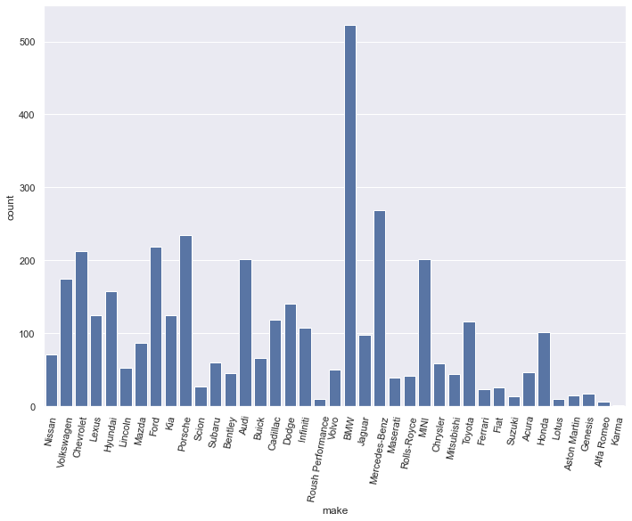

```python
sns.set(rc={'figure.figsize':(11.7,8.27)})
base_color = sns.color_palette()[0]
sns.countplot(data=df_clean, x='make', color=base_color, );
plt.xticks(rotation=80);
```

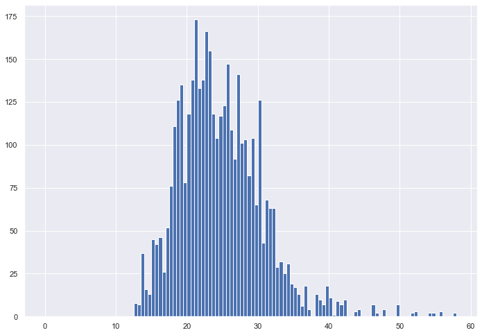

```python
bins = np.arange(0, df_clean['comb'].max()+0.5, 0.5)

# Plot the histogram for the height column
plt.hist(data=df_clean, x='comb', bins=bins);
```

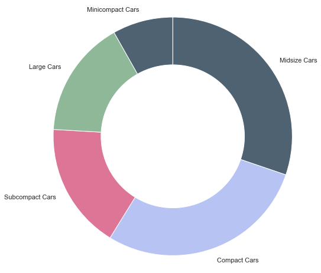

```python
colors = ['#4F6272', '#B7C3F3', '#DD7596', '#8EB897']
sorted_counts = df_clean['VClass'].value_counts()

plt.pie(sorted_counts, labels = sorted_counts.index, startangle = 90,
        counterclock = False, wedgeprops = {'width' : 0.4}, colors=colors);
plt.axis('square');
```

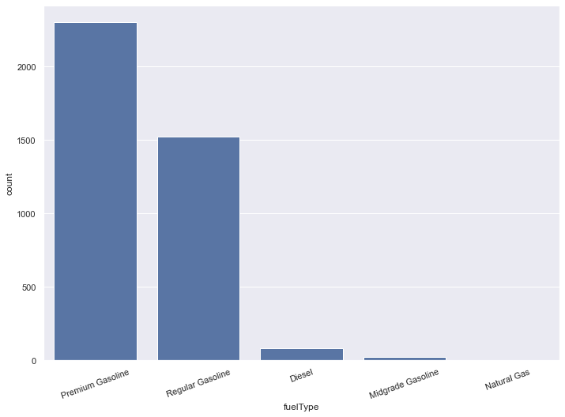

```python
base_color = sns.color_palette()[0]
sns.countplot(data=df_clean, x='fuelType', color=base_color);
plt.xticks(rotation=20);
```

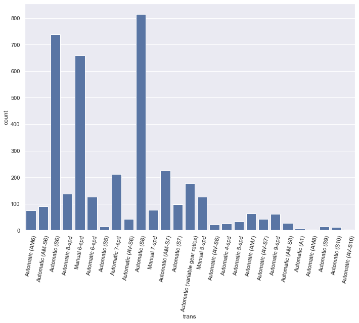

```python
base_color = sns.color_palette()[0]
sns.countplot(data=df_clean, x='trans', color=base_color);
plt.xticks(rotation=80);
```

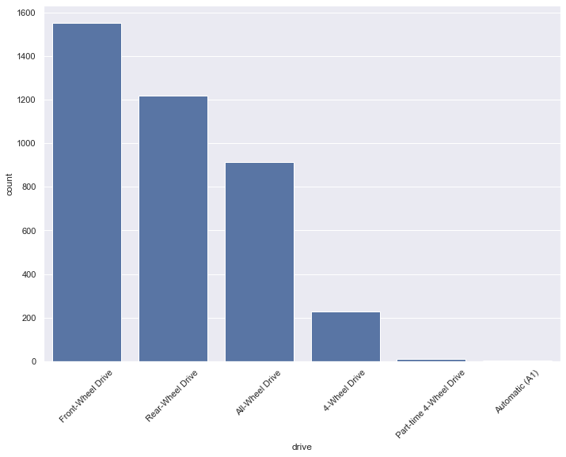

```python
base_color = sns.color_palette()[0]
sns.countplot(data=df_clean, x='drive', color=base_color, order = ['Front-Wheel Drive', 'Rear-Wheel Drive', 'All-Wheel Drive', '4-Wheel Drive','Part-time 4-Wheel Drive','Automatic (A1)']);
plt.xticks(rotation=45);
```

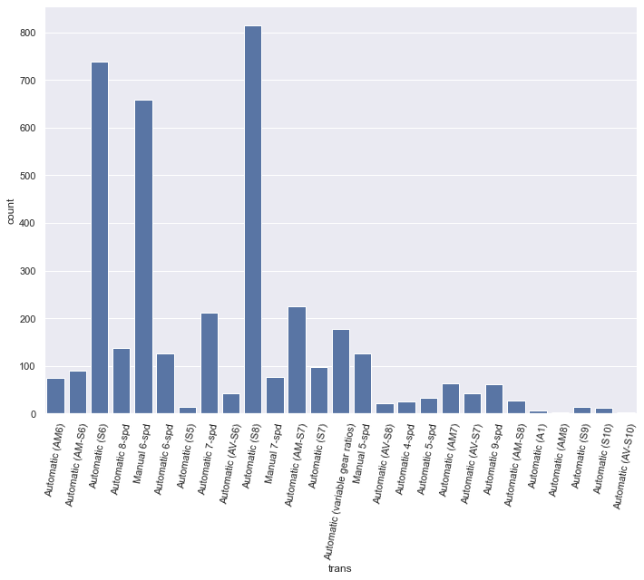

```python
base_color = sns.color_palette()[0]
sns.countplot(data=df_clean, x='trans', color=base_color);
plt.xticks(rotation=80);
```

### Discuss the distribution(s) of your variable(s) of interest. Were there any unusual points? Did you need to perform any transformations?

> Transformation performed involved converting the "VClass" column from a object data type into an ordered categorical type which are much easier to visualize.

### Of the features you investigated, were there any unusual distributions? Did you perform any operations on the data to tidy, adjust, or change the form of the data? If so, why did you do this?

> There were various variables with outliers in their visualizations such as transmission type(trans), fuel_type, drive, make and combustion(comb) variables. The data set was analyzed for null values using the .isnull() function and duplicates using the .duplicated() function and was found to be tidy and ready for analysis.

## Bivariate Exploration

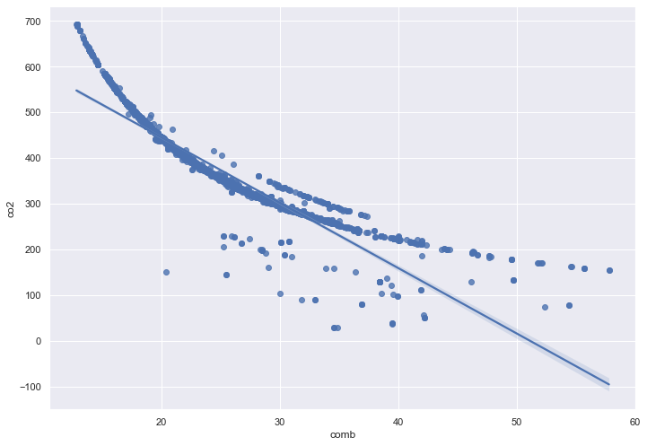

```python
sns.regplot(data = df_clean, x = 'comb', y = 'co2');
plt.xlabel('comb')
plt.ylabel('co2');
```

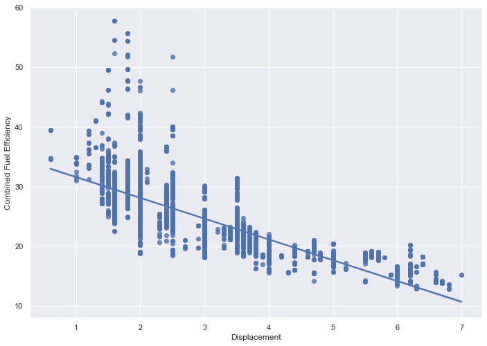

```python
sns.regplot(data = df_clean, x = 'displ', y = 'comb');
plt.xlabel('Displacement')
plt.ylabel('Combined Fuel Efficiency');
```

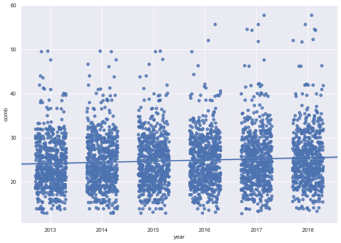

```python
sns.regplot(data = df_clean, x = 'year', y = 'comb', truncate=False, x_jitter=0.3);
```

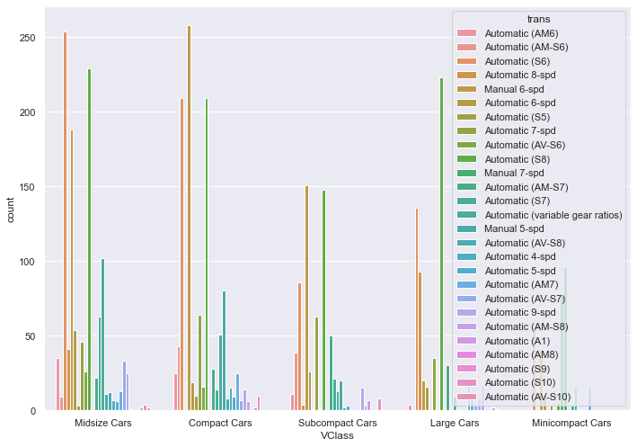

```python
sns.countplot(data = df_clean, x = 'VClass', hue = 'trans');
```

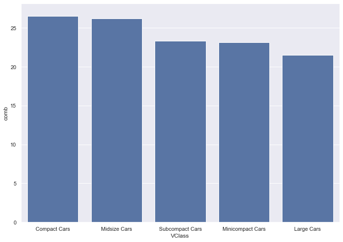

```python
sns.barplot(data=df_clean, x='VClass', y='comb', color=base_color, errwidth=0, order=['Compact Cars','Midsize Cars', 'Subcompact Cars','Minicompact Cars', 'Large Cars']);
```

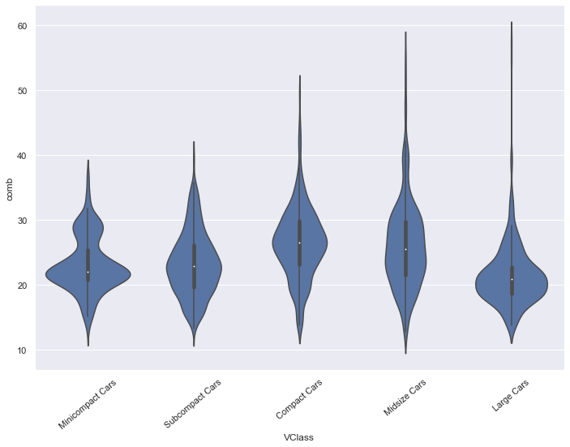

```python
sns.violinplot(data=df_clean, x='VClass', y='comb', color = base_color, order=['Minicompact Cars', 'Subcompact Cars', 'Compact Cars', 'Midsize Cars', 'Large Cars'])
plt.xticks(rotation = 40);
```

### Talk about some of the relationships you observed in this part of the investigation. How did the feature(s) of interest vary with other features in the dataset?

> Combined fuel efficiency has a high correlation with co2 emission. As more fuel is burnt, more co2 emission occurs. Fuel efficiency and fuel displacement are highly corrlated. As fuel is diplaced, it is combusted in the same proportion.

### Did you observe any interesting relationships between the other features (not the main feature(s) of interest)?

> Combined fuel efficiency and co2 emissions have a a highly negative correlation. This is also the same for variables fuel displacement(displ) and fuel efficiency.

## Multivariate Exploration

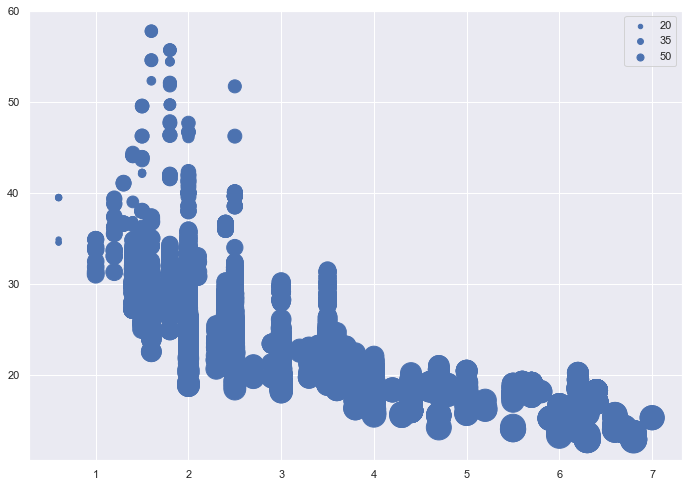

```python
plt.scatter(data = df_clean, x = 'displ', y = 'comb', s = 'co2')

# dummy series for adding legend
sizes = [20, 35, 50]
base_color = sns.color_palette()[0]
legend_object = []
for s in sizes:
    legend_object.append(plt.scatter([], [], s = s, color = base_color))
plt.legend(legend_object, sizes);
```

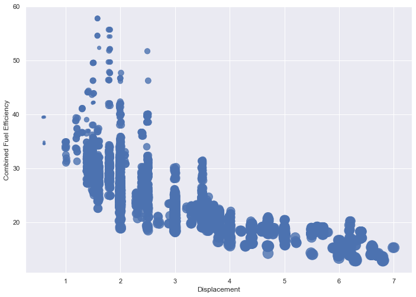

```python
sns.regplot(data = df_clean, x = 'displ', y= 'comb', x_jitter = 0.02, fit_reg = False, scatter_kws = {'s': df_clean['co2']/2});
plt.xlabel('Displacement')
plt.ylabel('Combined Fuel Efficiency');
```

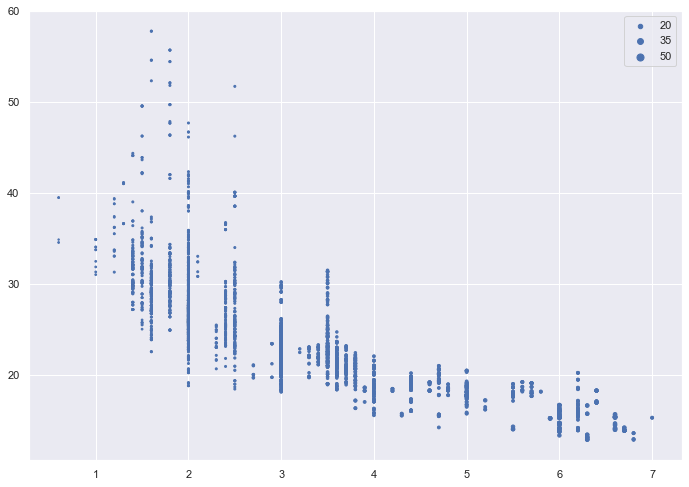

```python
plt.scatter(data = df_clean, x = 'displ', y = 'comb', s = 'cylinders')

# dummy series for adding legend
sizes = [20, 35, 50]
base_color = sns.color_palette()[0]
legend_object = []
for s in sizes:
    legend_object.append(plt.scatter([], [], s = s, color = base_color))
plt.legend(legend_object, sizes);
```

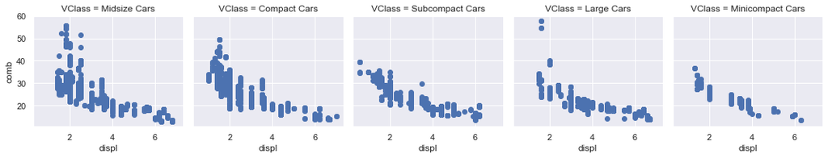

```python
g = sns.FacetGrid(data = df_clean, col = 'VClass')
g.map(plt.scatter, 'displ', 'comb');
```

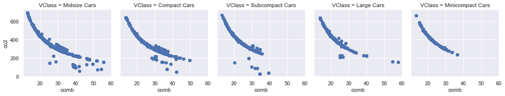

```python
g = sns.FacetGrid(data = df_clean, col = 'VClass')
g.map(plt.scatter, 'comb', 'co2');
```

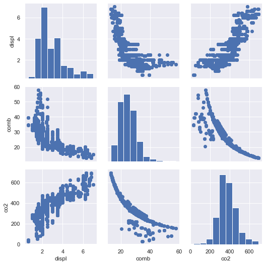

```python
g = sns.PairGrid(data = df, vars = ['displ', 'comb', 'co2'])
g.map_diag(plt.hist)
g.map_offdiag(plt.scatter);
```

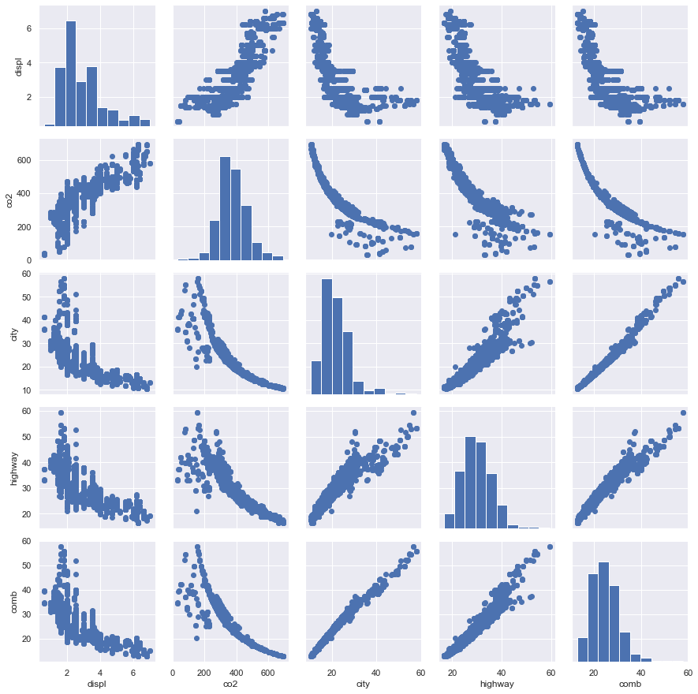

```python
g = sns.PairGrid(data = df_clean, vars = ['displ', 'co2', 'city', 'highway', 'comb'])
g.map_diag(plt.hist)
g.map_offdiag(plt.scatter);
```

### Talk about some of the relationships you observed in this part of the investigation. Were there features that strengthened each other in terms of looking at your feature(s) of interest?

> Investigation of fuel efficiency against fuel combustion in this section was further looked into by looking at the impact of the three features. The multivariate exploration showed that there is a relationship between the amount of fuel displaced , combined fuel efficiency and co2 emissions.

### Were there any interesting or surprising interactions between features?

> The three features are closely dependent on each other as the occurence of one variable results to the occurrence of either the other variables.